# dementia_age case

# 1 Description of DataSchema variable

The description of harmonised variable is the following:

- Short name: `dementia_age`
- Variable label: `Age of dementia diagnosis`
- Variable description: `Age of dementia diagnosis`
- Domain: `Psychological measures`
- Value type: `Continuous`
- Category coding:
- Category missings:

| **Code** | **Category Label** |
| --- | --- |
| 991 | CAPI/interviewer error |
| 992 | Impute |
| 993 | Disable to measure |
| 994 | Not attempt/not done |
| 995 | Does not answer |
| 996 | Not applicable |
| 997 | Refuse |
| 998 | Do not know |
| 999 | Missing |

# 2 Data process

## 2.1 England

### 2.1.1 Wave 1

#### 2.1.1.1 Study-specific variable description

| **Name** | `HeAgj` | `HeAgjRY` |
| --- | --- | --- |
| **Label** | `Age told had dementia` | `Year told had dementia since last interview` |
| **Table name** | `wave_3_elsa_data_v4` | `wave_3_elsa_data_v4` |
| **Missing** | `-9 = Refusal` `-8 = Don't Know` `-1 = Item not applicable` | `-9 = Refusal` `-8 = Don't Know` `-1 = Item not applicable` |
| **Description** |  |  |

| Sample size | Missing values |
| --- | --- |
| 12099 | 0 |

values

|  | No-missings | -1 | -8 | -9 | NA |
| --- | --- | --- | --- | --- | --- |
| Frequency | 12099 | 0 | 0 | 0 | 0 |
| Percentage | 100 | 0 | 0 | 0 | 0 |

Summary

| Min. | 1st Qu. | Median | Mean | 3rd Qu. | Max. |
| --- | --- | --- | --- | --- | --- |
| 0 | 0 | 0 | 340.4 | 999 | 999 |

[figure not shown]

(en) Age told had dementia

| Sample size | Missing values |
| --- | --- |
| 12099 | 12099 |

values

|  | No-missings | -1 | -8 | -9 | NA |
| --- | --- | --- | --- | --- | --- |
| Frequency | 0 | 7976.00 | 0 | 0 | 4123.00 |
| Percentage | 0 | 65.92 | 0 | 0 | 34.08 |

Summary

| Min. | 1st Qu. | Median | Mean | 3rd Qu. | Max. |
| --- | --- | --- | --- | --- | --- |
| NA | NA | NA | NA | NA | NA |

[figure not shown]

#### 2.1.1.2 Harmonisation algorithm

To compute the harmonized variable from the study-specific variable it has to be computed as follows:

`heagjry - ybirth` or `heagj`

and the missing values have to be recoded as follows:

- `-9 into 997`
- `-8 into 998`
- `-1 into 996`
- `NA into 996`

**R script:**

```r
ELSA_ds_w1 <- tibble(id = ELSA_dem_a$id)
ELSA_ds_w1$dementia_age <- ELSA_dem_a$heagjry - ELSA_dem_a$ybirth

ELSA_ds_w1$dementia_age[ELSA_dem_a$heagjry == -1] <- 996
ELSA_ds_w1$dementia_age[ELSA_dem_a$heagjry == -8] <- 998
ELSA_ds_w1$dementia_age[ELSA_dem_a$heagjry == -9] <- 997

ELSA_ds_w1$dementia_age[ELSA_dem_a$dementia == 1 & ELSA_dem_a$heagjry %in% c(-8,
    -2, -1)] <- car::recode(ELSA_dem_a$heagj[ELSA_dem_a$dementia == 1 & ELSA_dem_a$heagjry %in%
    c(-8, -2, -1)], "-9=997; -8=998; -1=996")

ELSA_ds_w1$dementia_age[ELSA_ds_w1$dementia_age == 996 & ELSA_dem_a$dementia ==
    1] <- 999
ELSA_ds_w1$dementia_age[ELSA_dem_a$dementia == 0] <- 996
```

#### 2.1.1.3 Statistical description of the new harmonised variable

dementia age

| Sample size | Missing values |
| --- | --- |
| 12099 | 12099 |

Values

|  | No-missings | 991 | 992 | 993 | 994 | 995 | 996 | 997 | 998 | 999 | NA |
| --- | --- | --- | --- | --- | --- | --- | --- | --- | --- | --- | --- |
| Frequency | 0 | 0 | 0 | 0 | 0 | 0 | 7949.0 | 0 | 0 | 27.00 | 4123.00 |
| Percentage | 0 | 0 | 0 | 0 | 0 | 0 | 65.7 | 0 | 0 | 0.22 | 34.08 |

Summary

| Min. | 1st Qu. | Median | Mean | 3rd Qu. | Max. |
| --- | --- | --- | --- | --- | --- |
| NA | NA | NA | NA | NA | NA |

[figure not shown]

#### 2.1.1.4 Validation

### 2.1.2 Wave 2

#### 2.1.2.1 Study-specific variable description

| **Name** | `HeAgj` | `HeAgjRY` |
| --- | --- | --- |
| **Label** | `Age told had dementia` | `Year told had dementia since last interview` |
| **Table name** | `wave_3_elsa_data_v4` | `wave_3_elsa_data_v4` |
| **Missing** | `-9 = Refusal` `-8 = Don't Know` `-1 = Item not applicable` | `-9 = Refusal` `-8 = Don't Know` `-1 = Item not applicable` |
| **Description** |  |  |

| Sample size | Missing values |
| --- | --- |
| 9432 | 0 |

values

|  | No-missings | -1 | -8 | -9 | NA |
| --- | --- | --- | --- | --- | --- |
| Frequency | 9432 | 0 | 0 | 0 | 0 |
| Percentage | 100 | 0 | 0 | 0 | 0 |

Summary

| Min. | 1st Qu. | Median | Mean | 3rd Qu. | Max. |
| --- | --- | --- | --- | --- | --- |
| 0 | 0 | 0 | 185.6 | 0 | 999 |

[figure not shown]

(en) Age told had dementia

| Sample size | Missing values |
| --- | --- |
| 9432 | 9432 |

values

|  | No-missings | -1 | -8 | -9 | NA |
| --- | --- | --- | --- | --- | --- |
| Frequency | 0 | 7680.00 | 0 | 0 | 1752.00 |
| Percentage | 0 | 81.42 | 0 | 0 | 18.58 |

Summary

| Min. | 1st Qu. | Median | Mean | 3rd Qu. | Max. |
| --- | --- | --- | --- | --- | --- |
| NA | NA | NA | NA | NA | NA |

[figure not shown]

#### 2.1.2.2 Harmonisation algorithm

To compute the harmonized variable from the study-specific variable it has to be computed as follows:

`heagjry - ybirth` or `heagj`

and the missing values have to be recoded as follows:

- `-9 into 997`
- `-8 into 998`
- `-1 into 996`
- `NA into 996`

**R script:**

```r
ELSA_ds_w2 <- tibble(id = ELSA_dem_a$id)
ELSA_ds_w2$dementia_age <- ELSA_dem_a$heagjry - ELSA_dem_a$ybirth

ELSA_ds_w2$dementia_age[ELSA_dem_a$heagjry == -1] <- 996
ELSA_ds_w2$dementia_age[ELSA_dem_a$heagjry == -8] <- 998
ELSA_ds_w2$dementia_age[ELSA_dem_a$heagjry == -9] <- 997

ELSA_ds_w2$dementia_age[ELSA_dem_a$dementia == 1 & ELSA_dem_a$heagjry %in% c(-8,
    -2, -1)] <- car::recode(ELSA_dem_a$heagj[ELSA_dem_a$dementia == 1 & ELSA_dem_a$heagjry %in%
    c(-8, -2, -1)], "-9=997; -8=998; -1=996")

ELSA_ds_w2$dementia_age[ELSA_ds_w2$dementia_age == 996 & ELSA_dem_a$dementia ==
    1] <- 999
ELSA_ds_w2$dementia_age[ELSA_dem_a$dementia == 0] <- 996
```

#### 2.1.2.3 Statistical description of the new harmonised variable

dementia age

| Sample size | Missing values |
| --- | --- |
| 9432 | 9432 |

Values

|  | No-missings | 991 | 992 | 993 | 994 | 995 | 996 | 997 | 998 | 999 | NA |
| --- | --- | --- | --- | --- | --- | --- | --- | --- | --- | --- | --- |
| Frequency | 0 | 0 | 0 | 0 | 0 | 0 | 7629.00 | 0 | 0 | 51.00 | 1752.00 |
| Percentage | 0 | 0 | 0 | 0 | 0 | 0 | 80.88 | 0 | 0 | 0.54 | 18.58 |

Summary

| Min. | 1st Qu. | Median | Mean | 3rd Qu. | Max. |
| --- | --- | --- | --- | --- | --- |
| NA | NA | NA | NA | NA | NA |

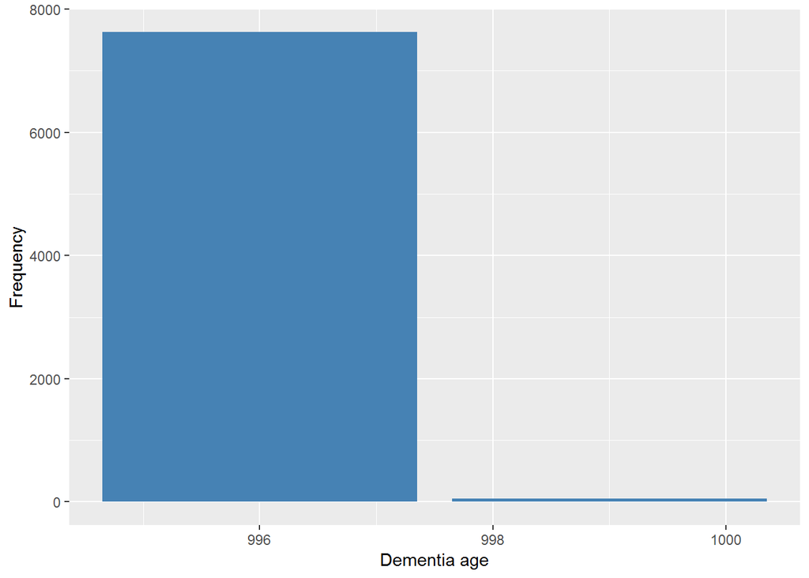

### 2.1.3 Wave 3

#### 2.1.3.1 Study-specific variable description

| **Name** | `HeAgj` | `HeAgjRY` |
| --- | --- | --- |
| **Label** | `Age told had dementia` | `Year told had dementia since last interview` |
| **Table name** | `wave_3_elsa_data_v4` | `wave_3_elsa_data_v4` |
| **Missing** | `-9 = Refusal` `-8 = Don't Know` `-1 = Item not applicable` | `-9 = Refusal` `-8 = Don't Know` `-1 = Item not applicable` |
| **Description** |  |  |

(en) Age told had dementia

| Sample size | Missing values |
| --- | --- |
| 9771 | 9768 |

values

|  | No-missings | -1 | -8 | -9 | NA |
| --- | --- | --- | --- | --- | --- |
| Frequency | 3.00 | 9768.00 | 0 | 0 | 0 |
| Percentage | 0.03 | 99.97 | 0 | 0 | 0 |

Summary

| Min. | 1st Qu. | Median | Mean | 3rd Qu. | Max. |
| --- | --- | --- | --- | --- | --- |
| 24 | 31 | 38 | 44 | 54 | 70 |

[figure not shown]

(en) Year told had dementia since last interview

| Sample size | Missing values |
| --- | --- |
| 9771 | 9723 |

values

|  | No-missings | -1 | -8 | -9 | NA |
| --- | --- | --- | --- | --- | --- |
| Frequency | 48.00 | 9716.00 | 7.00 | 0 | 0 |
| Percentage | 0.49 | 99.44 | 0.07 | 0 | 0 |

Summary

| Min. | 1st Qu. | Median | Mean | 3rd Qu. | Max. |
| --- | --- | --- | --- | --- | --- |
| 1985 | 2004 | 2005 | 2004 | 2006 | 2006 |

[figure not shown]

#### 2.1.3.2 Harmonisation algorithm

To compute the harmonized variable from the study-specific variable it has to be computed as follows:

`heagjry - ybirth` or `heagj`

and the missing values have to be recoded as follows:

- `-9 into 997`
- `-8 into 998`
- `-1 into 996`
- `NA into 996`

**R script:**

```r
ELSA_ds_w3 <- tibble(id = ELSA_dem_a$id)
ELSA_ds_w3$dementia_age <- ELSA_dem_a$heagjry - ELSA_dem_a$ybirth

ELSA_ds_w3$dementia_age[ELSA_dem_a$heagjry == -1] <- 996
ELSA_ds_w3$dementia_age[ELSA_dem_a$heagjry == -8] <- 998
ELSA_ds_w3$dementia_age[ELSA_dem_a$heagjry == -9] <- 997

ELSA_ds_w3$dementia_age[ELSA_dem_a$dementia == 1 & ELSA_dem_a$heagjry %in% c(-8,
    -2, -1)] <- car::recode(ELSA_dem_a$heagj[ELSA_dem_a$dementia == 1 & ELSA_dem_a$heagjry %in%
    c(-8, -2, -1)], "-9=997; -8=998; -1=996")

ELSA_ds_w3$dementia_age[ELSA_ds_w3$dementia_age == 996 & ELSA_dem_a$dementia ==
    1] <- 999
```

#### 2.1.3.3 Statistical description of the new harmonised variable

dementia age

| Sample size | Missing values |
| --- | --- |
| 9771 | 9720 |

Values

|  | No-missings | 991 | 992 | 993 | 994 | 995 | 996 | 997 | 998 | 999 | NA |
| --- | --- | --- | --- | --- | --- | --- | --- | --- | --- | --- | --- |
| Frequency | 51.00 | 0 | 0 | 0 | 0 | 0 | 9659.00 | 0 | 0 | 61.00 | 0 |
| Percentage | 0.52 | 0 | 0 | 0 | 0 | 0 | 98.85 | 0 | 0 | 0.62 | 0 |

Summary

| Min. | 1st Qu. | Median | Mean | 3rd Qu. | Max. |
| --- | --- | --- | --- | --- | --- |
| 24 | 71.5 | 81 | 76.57 | 85.5 | 94 |

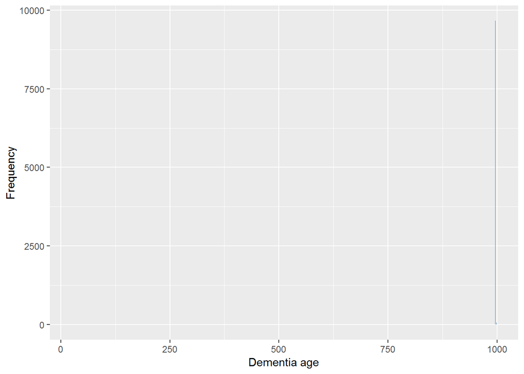

#### 2.1.3.4 Validation

### 2.1.4 Wave 4

#### 2.1.4.1 Study-specific variable description

| **Name** | `heagj` | `heagjry` |
| --- | --- | --- |
| **Label** | `Age told had dementia` | `Year told had dementia since last interview` |
| **Table name** | `wave_4_elsa_data_v3` | `wave_4_elsa_data_v3` |
| **Missing** | `-9 = Refusal` `-8 = Don't know` `-2 = Capi/Interview Error` `-1 = Not applicable` | `-9 = Refusal` `-8 = Don't know` `-2 = Capi/Interview Error` `-1 = Not applicable` |
| **Description** |  |  |

(en) Age told had dementia

| Sample size | Missing values |
| --- | --- |
| 11050 | 11030 |

values

|  | No-missings | -1 | -8 | -9 | -2 | NA |
| --- | --- | --- | --- | --- | --- | --- |
| Frequency | 20.00 | 10956.00 | 2.00 | 0 | 72.00 | 0 |
| Percentage | 0.18 | 99.15 | 0.02 | 0 | 0.65 | 0 |

Summary

| Min. | 1st Qu. | Median | Mean | 3rd Qu. | Max. |
| --- | --- | --- | --- | --- | --- |
| 45 | 58.75 | 72.5 | 68.2 | 79.25 | 89 |

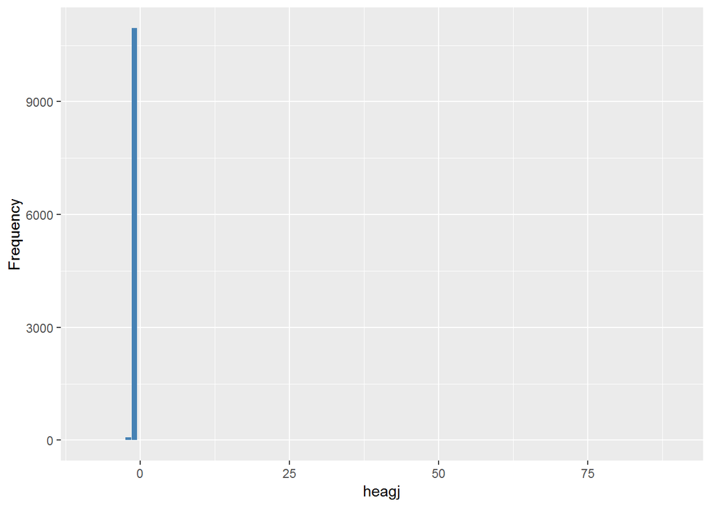

(en) Year told had dementia since last interview

| Sample size | Missing values |
| --- | --- |
| 11050 | 10983 |

values

|  | No-missings | -1 | -8 | -9 | -2 | NA |
| --- | --- | --- | --- | --- | --- | --- |
| Frequency | 67.00 | 10907.00 | 4.00 | 0 | 72.00 | 0 |
| Percentage | 0.61 | 98.71 | 0.04 | 0 | 0.65 | 0 |

Summary

| Min. | 1st Qu. | Median | Mean | 3rd Qu. | Max. |
| --- | --- | --- | --- | --- | --- |
| 1999 | 2006 | 2007 | 2006 | 2008 | 2009 |

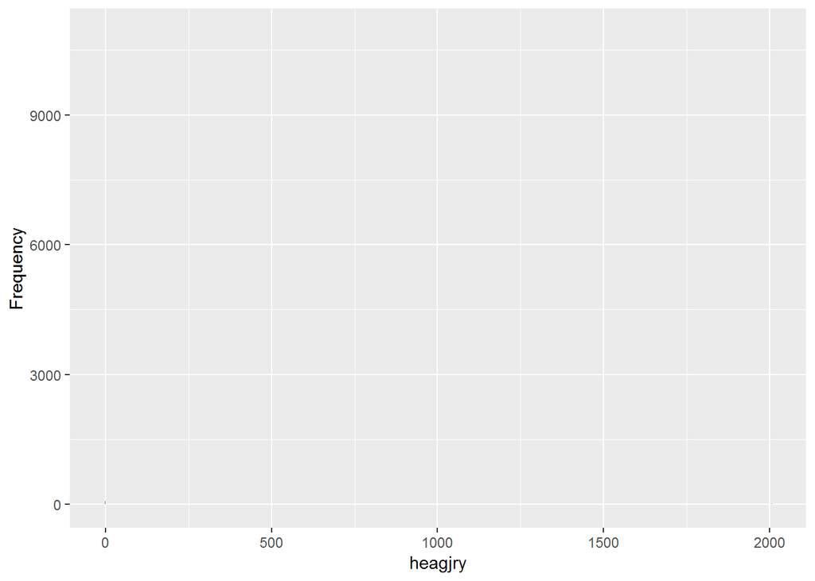

#### 2.1.4.2 Harmonisation algorithm

To compute the harmonized variable from the study-specific variable it has to be computed as follows:

`heagjry - ybirth` or `heagj`

and the missing values have to be recoded as follows:

- `-9 into 997`
- `-8 into 998`
- `-1 into 996`
- `-2 into 991`
- `NA into 996`

**R script:**

```r
ELSA_ds_w4 <- tibble(id = ELSA_dem_a$id)
ELSA_ds_w4$dementia_age <- ELSA_dem_a$heagjry - ELSA_dem_a$ybirth

ELSA_ds_w4$dementia_age[ELSA_dem_a$heagjry == -1] <- 996
ELSA_ds_w4$dementia_age[ELSA_dem_a$heagjry == -8] <- 998
ELSA_ds_w4$dementia_age[ELSA_dem_a$heagjry == -9] <- 997
ELSA_ds_w4$dementia_age[ELSA_dem_a$heagjry == -2] <- 991

ELSA_ds_w4$dementia_age[ELSA_dem_a$dementia == 1 & ELSA_dem_a$heagjry %in% c(-8,
    -2, -1)] <- car::recode(ELSA_dem_a$heagj[ELSA_dem_a$dementia == 1 & ELSA_dem_a$heagjry %in%
    c(-8, -2, -1)], "-9=997; -8=998; -1=996")

ELSA_ds_w4$dementia_age[ELSA_ds_w4$dementia_age == 996 & ELSA_dem_a$dementia ==
    1] <- 999
```

#### 2.1.4.3 Statistical description of the new harmonised variable

dementia age

| Sample size | Missing values |
| --- | --- |
| 11050 | 10978 |

Values

|  | No-missings | 991 | 992 | 993 | 994 | 995 | 996 | 997 | 998 | 999 | NA |
| --- | --- | --- | --- | --- | --- | --- | --- | --- | --- | --- | --- |
| Frequency | 72.00 | 71.00 | 0 | 0 | 0 | 0 | 10837.00 | 0 | 2.00 | 59.00 | 9.00 |
| Percentage | 0.65 | 0.64 | 0 | 0 | 0 | 0 | 98.07 | 0 | 0.02 | 0.53 | 0.08 |

Summary

| Min. | 1st Qu. | Median | Mean | 3rd Qu. | Max. |
| --- | --- | --- | --- | --- | --- |
| -2 | 69 | 80 | 75.36 | 85 | 94 |

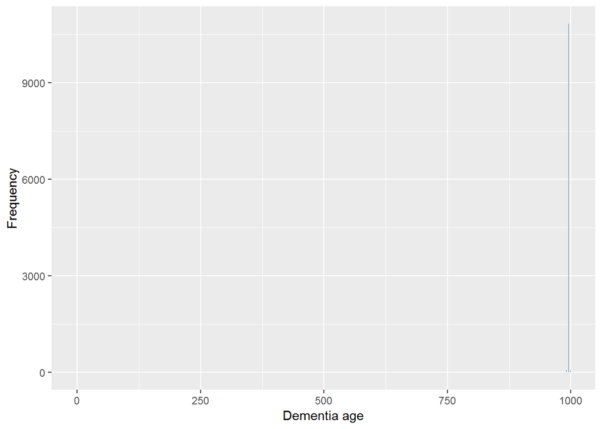

#### 2.1.4.4 Validation

### 2.1.5 Wave 5

#### 2.1.5.1 Study-specific variable description

| **Name** | `heagjry` |
| --- | --- |
| **Label** | `Year told had dementia since last interview` |
| **Table name** | `wave_5_elsa_data_v4` |
| **Missing** | `-9 = Refusal` `-8 = Don't know` `-1 = Item Not Applicable` |
| **Description** |  |

(en) Year told had dementia since last interview

| Sample size | Missing values |
| --- | --- |
| 10274 | 10202 |

values

|  | No-missings | -1 | -8 | -9 | NA |
| --- | --- | --- | --- | --- | --- |
| Frequency | 72.0 | 10197.00 | 5.00 | 0 | 0 |
| Percentage | 0.7 | 99.25 | 0.05 | 0 | 0 |

Summary

| Min. | 1st Qu. | Median | Mean | 3rd Qu. | Max. |
| --- | --- | --- | --- | --- | --- |
| 1954 | 2008 | 2009 | 2007 | 2010 | 2011 |

[figure not shown]

#### 2.1.5.2 Harmonisation algorithm

To compute the harmonized variable from the study-specific variable it has to be computed as follows:

`heagjry - ybirth`

and the missing values have to be recoded as follows:

- `-9 into 997`
- `-8 into 998`
- `-1 into 996`
- `NA into 996`

**R script:**

```r
ELSA_ds_w5 <- tibble(id = ELSA_dem_a$id)
ELSA_ds_w5$dementia_age <- ELSA_dem_a$heagjry - ELSA_dem_a$ybirth

ELSA_ds_w5$dementia_age[ELSA_dem_a$heagjry == -1] <- 996
ELSA_ds_w5$dementia_age[ELSA_dem_a$heagjry == -8] <- 998
ELSA_ds_w5$dementia_age[ELSA_dem_a$heagjry == -9] <- 997

ELSA_ds_w5$dementia_age[ELSA_ds_w5$dementia_age == 996 & ELSA_dem_a$dementia ==
    1] <- 999
```

#### 2.1.5.3 Statistical description of the new harmonised variable

dementia age

| Sample size | Missing values |
| --- | --- |
| 10274 | 10202 |

Values

|  | No-missings | 991 | 992 | 993 | 994 | 995 | 996 | 997 | 998 | 999 | NA |
| --- | --- | --- | --- | --- | --- | --- | --- | --- | --- | --- | --- |
| Frequency | 72.0 | 0 | 0 | 0 | 0 | 0 | 10103.00 | 0 | 5.00 | 94.00 | 0 |
| Percentage | 0.7 | 0 | 0 | 0 | 0 | 0 | 98.34 | 0 | 0.05 | 0.91 | 0 |

Summary

| Min. | 1st Qu. | Median | Mean | 3rd Qu. | Max. |
| --- | --- | --- | --- | --- | --- |
| 0 | 73.75 | 81 | 77.89 | 86 | 96 |

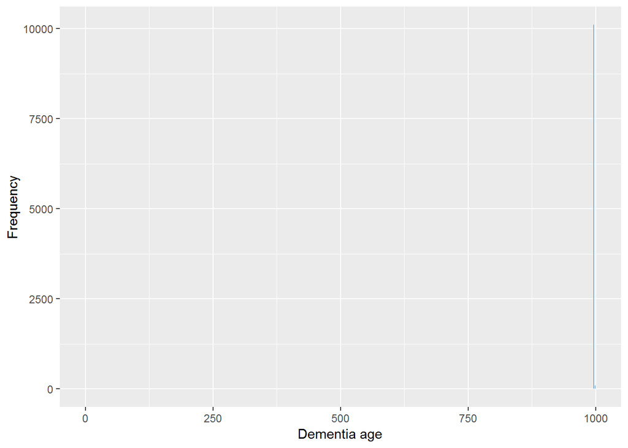

#### 2.1.5.4 Validation

### 2.1.6 Wave 6

#### 2.1.6.1 Study-specific variable description

| **Name** | `HeAgj` | `HeAgjRY` |
| --- | --- | --- |
| **Label** | `Age told had dementia` | `Year told had dementia since last interview` |
| **Table name** | `wave_6_elsa_data_v2` | `wave_6_elsa_data_v2` |
| **Missing** | `-9 = Refusal` `-8 = Don't Know` `-1 = Item not applicable` | `-9 = Refusal` `-8 = Don't Know` `-1 = Item not applicable` |
| **Description** |  |  |

(en) Age told had dementia

| Sample size | Missing values |
| --- | --- |
| 10601 | 10595 |

values

|  | No-missings | -1 | -8 | -9 | NA |
| --- | --- | --- | --- | --- | --- |
| Frequency | 6.00 | 10595.00 | 0 | 0 | 0 |
| Percentage | 0.06 | 99.94 | 0 | 0 | 0 |

Summary

| Min. | 1st Qu. | Median | Mean | 3rd Qu. | Max. |
| --- | --- | --- | --- | --- | --- |
| 52 | 56.75 | 66 | 68.17 | 81.25 | 85 |

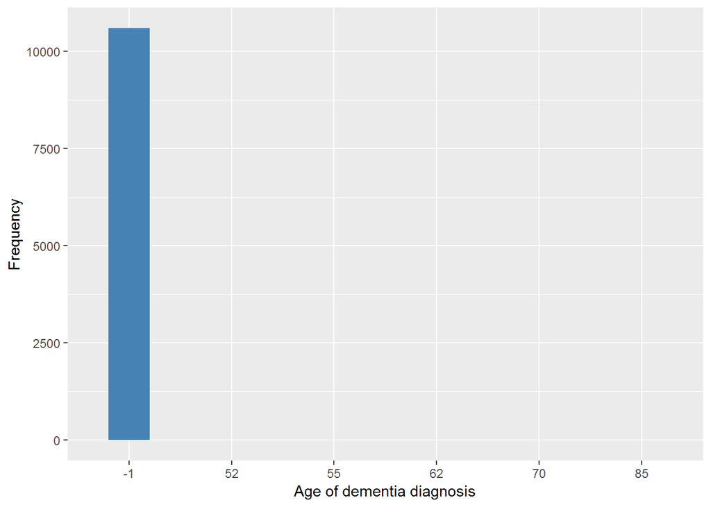

(en) Year told had dementia since last interview

| Sample size | Missing values |
| --- | --- |
| 10601 | 10534 |

values

|  | No-missings | -1 | -8 | -9 | NA |
| --- | --- | --- | --- | --- | --- |
| Frequency | 67.00 | 10524.00 | 10.00 | 0 | 0 |
| Percentage | 0.63 | 99.27 | 0.09 | 0 | 0 |

Summary

| Min. | 1st Qu. | Median | Mean | 3rd Qu. | Max. |
| --- | --- | --- | --- | --- | --- |
| 1999 | 2010 | 2011 | 2010 | 2012 | 2012 |

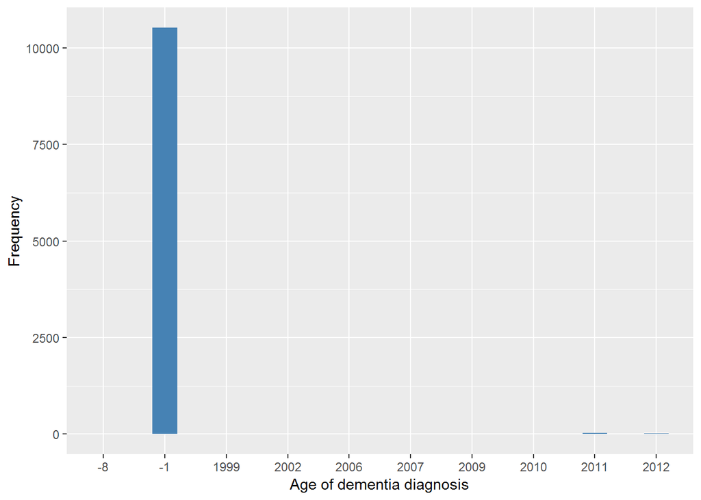

#### 2.1.6.2 Harmonisation algorithm

To compute the harmonized variable from the study-specific variable it has to be computed as follows:

`HeAgjRY - ybirth` or `HeAgj`

and the missing values have to be recoded as follows:

- `-9 into 997`
- `-8 into 998`
- `-1 into 996`
- `NA into 996`

**R script:**

```r
ELSA_ds_w6 <- tibble(id = ELSA_dem_a$id)
ELSA_ds_w6$dementia_age <- ELSA_dem_a$HeAgjRY - ELSA_dem_a$ybirth

ELSA_ds_w6$dementia_age[ELSA_dem_a$HeAgjRY == -1] <- 996
ELSA_ds_w6$dementia_age[ELSA_dem_a$HeAgjRY == -8] <- 998
ELSA_ds_w6$dementia_age[ELSA_dem_a$HeAgjRY == -9] <- 997

ELSA_ds_w6$dementia_age[ELSA_dem_a$dementia == 1 & ELSA_dem_a$HeAgjRY %in% c(-8,
    -1)] <- car::recode(ELSA_dem_a$HeAgj[ELSA_dem_a$dementia == 1 & ELSA_dem_a$HeAgjRY %in%
    c(-8, -1)], "-9=997; -8=998; -1=996")


ELSA_ds_w6$dementia_age[ELSA_ds_w6$dementia_age == 996 & ELSA_dem_a$dementia ==
    1] <- 999
```

#### 2.1.6.3 Statistical description of the new harmonised variable

dementia age

| Sample size | Missing values |
| --- | --- |
| 10601 | 10528 |

Values

|  | No-missings | 991 | 992 | 993 | 994 | 995 | 996 | 997 | 998 | 999 | NA |
| --- | --- | --- | --- | --- | --- | --- | --- | --- | --- | --- | --- |
| Frequency | 73.00 | 0 | 0 | 0 | 0 | 0 | 10489.00 | 0 | 0 | 39.00 | 0 |
| Percentage | 0.69 | 0 | 0 | 0 | 0 | 0 | 98.94 | 0 | 0 | 0.37 | 0 |

Summary

| Min. | 1st Qu. | Median | Mean | 3rd Qu. | Max. |
| --- | --- | --- | --- | --- | --- |
| 50 | 73 | 79 | 78.14 | 85 | 96 |

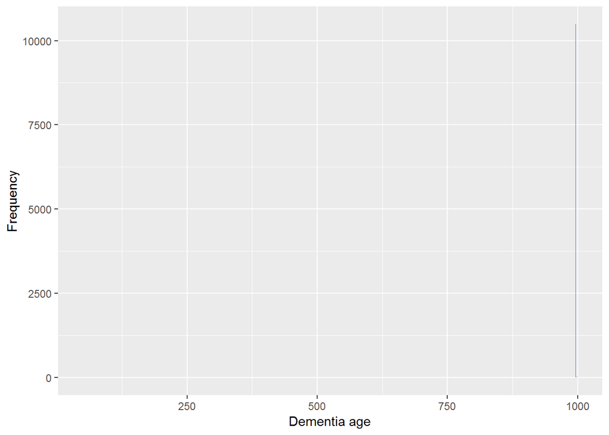

#### 2.1.6.4 Validation

### 2.1.7 Wave 7

#### 2.1.7.1 Study-specific variable description

| **Name** | `HeAgj` | `HeAgjRY` |
| --- | --- | --- |
| **Label** | `Age told had dementia` | `Year told had dementia since last interview` |
| **Table name** | `wave_6_elsa_data_v2` | `wave_6_elsa_data_v2` |
| **Missing** | `-9 = Refusal` `-8 = Don't Know` `-1 = Item not applicable` | `-9 = Refusal` `-8 = Don't Know` `-1 = Item not applicable` |
| **Description** |  |  |

(en) Age told had dementia

| Sample size | Missing values |
| --- | --- |
| 9666 | 9665 |

Category

|  | 37 |
| --- | --- |
| Frequency | 1.00 |
| Percentage | 0.01 |

Type of missing

|  | -1 | -8 | -9 | NA |
| --- | --- | --- | --- | --- |
| Frequency | 9665.00 | 0 | 0 | 0 |
| Percentage | 99.99 | 0 | 0 | 0 |

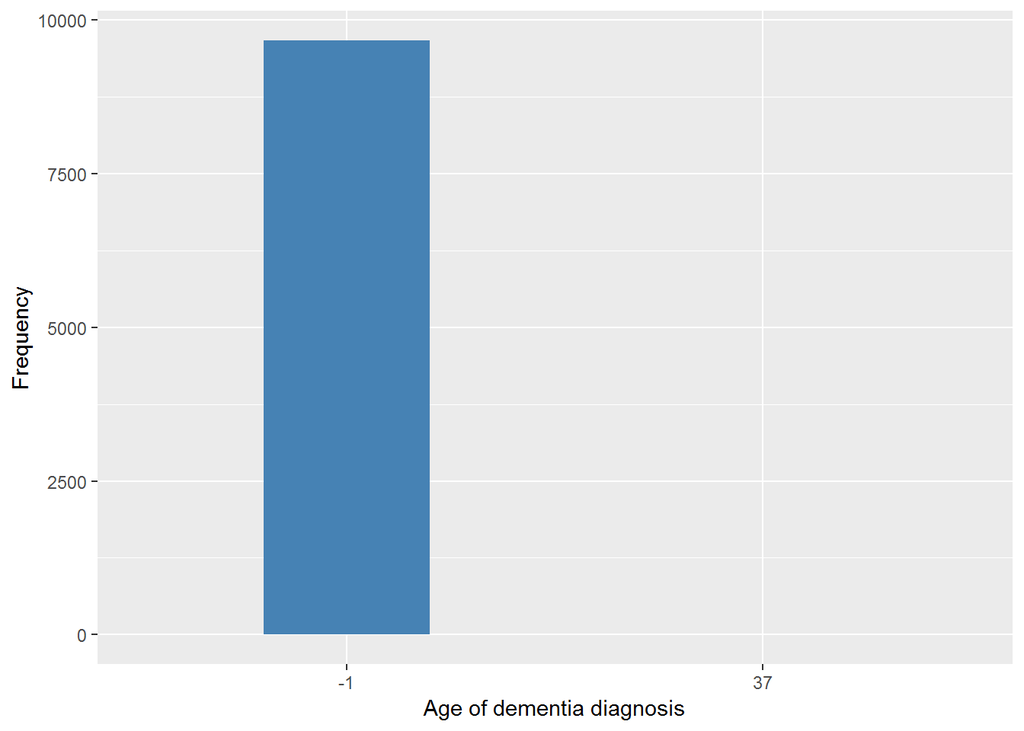

(en) Year told had dementia since last interview

| Sample size | Missing values |
| --- | --- |
| 9666 | 9590 |

Category

|  | 1989 | 2005 | 2006 | 2007 | 2008 | 2009 | 2011 | 2012 | 2013 | 2014 |
| --- | --- | --- | --- | --- | --- | --- | --- | --- | --- | --- |
| Frequency | 1.00 | 2.00 | 1.00 | 1.00 | 2.00 | 1.00 | 5.00 | 6.00 | 30.00 | 27.00 |
| Percentage | 0.01 | 0.02 | 0.01 | 0.01 | 0.02 | 0.01 | 0.05 | 0.06 | 0.31 | 0.28 |

Type of missing

|  | -1 | -8 | -9 | NA |
| --- | --- | --- | --- | --- |
| Frequency | 9585.00 | 5.00 | 0 | 0 |
| Percentage | 99.16 | 0.05 | 0 | 0 |

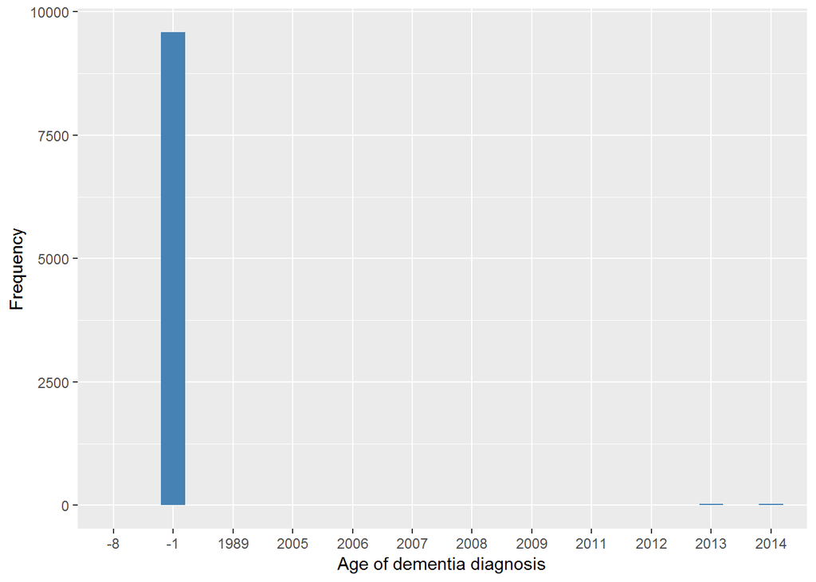

#### 2.1.7.2 Harmonisation algorithm

To compute the harmonized variable from the study-specific variable it has to be computed as follows:

`HeAgjRY - ybirth` or `HeAgj`

and the missing values have to be recoded as follows:

- `-9 into 997`
- `-8 into 998`
- `-1 into 996`
- `NA into 996`

**R script:**

```r
ELSA_ds_w7 <- tibble(id = ELSA_dem_a$id)
ELSA_ds_w7$dementia_age <- ELSA_dem_a$HeAgjRY - ELSA_dem_a$ybirth

ELSA_ds_w7$dementia_age[ELSA_dem_a$HeAgjRY == -1] <- 996
ELSA_ds_w7$dementia_age[ELSA_dem_a$HeAgjRY == -8] <- 998
ELSA_ds_w7$dementia_age[ELSA_dem_a$HeAgjRY == -9] <- 997

ELSA_ds_w7$dementia_age[ELSA_dem_a$dementia == 1 & ELSA_dem_a$HeAgjRY %in% c(-8,
    -1)] <- car::recode(ELSA_dem_a$HeAgj[ELSA_dem_a$dementia == 1 & ELSA_dem_a$HeAgjRY %in%
    c(-8, -1)], "-9=997; -8=998; -1=996")


ELSA_ds_w7$dementia_age[ELSA_ds_w7$dementia_age == 996 & ELSA_dem_a$dementia ==
    1] <- 999
```

#### 2.1.7.3 Statistical description of the new harmonised variable

dementia age

| Sample size | Missing values |
| --- | --- |
| 9666 | 9589 |

Values

|  | No-missings | 991 | 992 | 993 | 994 | 995 | 996 | 997 | 998 | 999 | NA |
| --- | --- | --- | --- | --- | --- | --- | --- | --- | --- | --- | --- |
| Frequency | 77.0 | 0 | 0 | 0 | 0 | 0 | 9552.00 | 0 | 0 | 37.00 | 0 |
| Percentage | 0.8 | 0 | 0 | 0 | 0 | 0 | 98.82 | 0 | 0 | 0.38 | 0 |

Summary

| Min. | 1st Qu. | Median | Mean | 3rd Qu. | Max. |
| --- | --- | --- | --- | --- | --- |
| 37 | 74 | 82 | 79.56 | 88 | 100 |

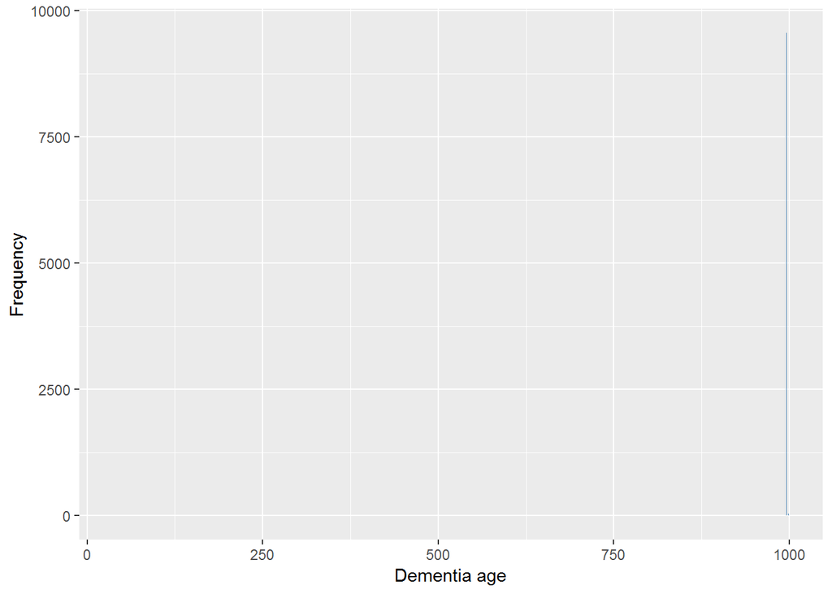

#### 2.1.7.4 Validation

# 3 Quality estimation

# 4 Quality estimation

No comments